# Transcriptomics with RNA-seq

Jelmer Poelstra

MCIC Wooster, OSU

2024-02-01

# Intro to transcriptomics & RNA-seq

## Recap: central dogma & omics

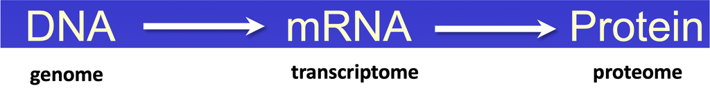

## The transcriptome

The transcriptome is the full set of transcripts expressed by an organism, which:

- **Is not at all stable across time & space** in any given organism  
  (unlike the genome but much like the proteome)
- Varies both **qualitatively** (which transcripts are expressed) but especially **quantitatively** (how much of each transcript is expressed)

## Transcriptomics

Transcriptomics is the study of the transcriptome,  
i.e. the **large-scale study of RNA transcripts expressed in an organism**.

Many approaches & applications — but most commonly, transcriptomics focuses on:

- **mRNA** rather than on noncoding RNA types such as rRNA, tRNA, and miRNA
- **Quantifying** gene expression levels (& ignoring nucleotide-level variation)
- **Statistically comparing** expression *between groups* (treatments, populations, tissues)

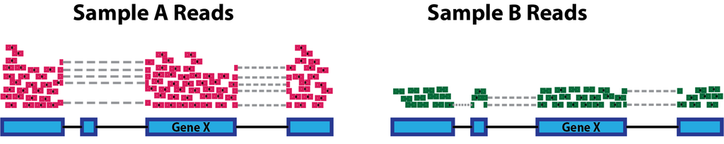

https://hbctraining.github.io

## Why do transcriptomics?

Considering…

- That protein production gives clues about the activity of specific biological functions, and the molecular mechanisms underlying those functions;
- That it is much easier to measure transcript expression than protein expression at scale;
- The central dogma

… we can use *gene expression levels as a proxy for protein expression levels* and make functional inferences.

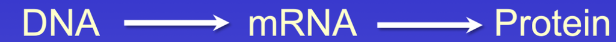

## Why do transcriptomics? (cont.)

Specifically, we can use transcriptomics to:

- Compare & contrast **phenotypic vs. molecular** responses/differences
- **Find the pathways and genes** that:
  - Underlie phenotypic responses
  - Explain differences between groups (treatments, genotypes, sexes, tissues, etc.)
  - Can be targeted to enhance or reduce organismal responses to help control pathogens and pests

## What is RNA-seq?

RNA-seq is the current state-of-the-art family of methods to study the transcriptome.  
It involves the **random sequencing of millions of transcript fragments per sample**.

We will focus on the most common type of RNA-seq, which:

- Does not actually sequence the RNA, but first **reverse transcribes RNA to cDNA**
- Attempts to sequence only mRNA while avoiding noncoding RNAs (“mRNA-seq”)
- Does not distinguish between RNA from different cell types (“**bulk RNA-seq**”)
- Uses **short reads** (≤150 bp) that do not cover full transcripts but do uniquely ID genes

## Other RNA-seq applications

RNA-seq data can also be used for **applications other than expression quantification**:

- **SNP** identification & analysis (for popgen, molecular evolution, functional associations)
- For organisms *without* a reference genome: **identify genes present in the organism**
- For organisms *with* a reference genome: **discover new genes & transcripts**,  
  and **improve genome annotation**

All in all, RNA-seq is a very widely used technique —  
it constitutes *the* most common usage of high-throughput sequencing!

## RNA-seq project examples

RNA-seq is also the most common data type I assist with as an MCIC bioinformatician. Some projects I’ve worked on used it **to identify genes & pathways that differ between**:

- Multiple soybean cultivars in response to *Phytophtora sojae* inoculation; soybean in response to different *Phytophtora* species and strains (Dorrance lab, PlantPath)
- Wheat vs. *Xanthomonas* with a gene knock-out vs. knock-in (Jacobs lab, PlantPath)
- Mated and unmated mosquitos (Sirot lab, College of Wooster)
- Tissues of the ambrosia beetle and its symbiotic fungus (Ranger lab, USDA Wooster)
- Diapause-inducing conditions for two pest stink bug species (Michel lab, Entomology)
- Human carcinoma cell lines with vs. without a manipulated gene (Cruz lab, CCC)
- Pig coronaviruses with vs. without an experimental insertion (Wang lab, CFAH)

And to improve the annotation of a nematode genome (Taylor lab, PlantPath)

# Experimental design

## Experimental design: groups & replicates

RNA-seq typically compares groups of samples defined by differences in:

- **Treatments** (e.g. different host plant, temperature, diet, mated/unmated) *and/or*
- **Organismal variants**: ages/developmental stages, sexes, or genotypes (lines/biotypes/subspecies/morphs) *and/or*
- **Tissues**

## Experimental design: groups & replicates

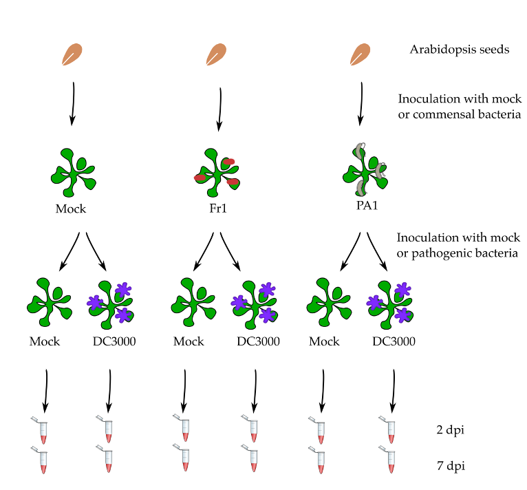

https://github.com/ScienceParkStudyGroup/rnaseq-lesson

## Experimental design: groups & replicates

To be able to make statistically supported conclusions about expression differences between such groups of samples, **we must have biological replication**.

When designing an RNA-seq experiment, keep the following in mind:

- **Numbers of replicates**  
  These are typically quite low: 3 replicates per treatment (x tissue x biotype, etc.) is the most common. Not advisable to go lower — if possible, use 4 or 5 replicates.
- **Statistical comparison design**  
  Preferably, keep your design relatively simple with 1-2 independent variables and 2-3 levels for each of them. Specifically, pairwise comparisons are easiest to interpret.

**Technical replicates?**

You won’t need technical replicates that only replicate library prep and/or sequencing, but depending on your experimental design, may want to technically replicate something else.

# From samples to reads

## From samples to reads: overview of steps

[figure not shown]

https://sydney-informatics-hub.github.io/training-RNAseq-slides

## RNA extraction & library prep

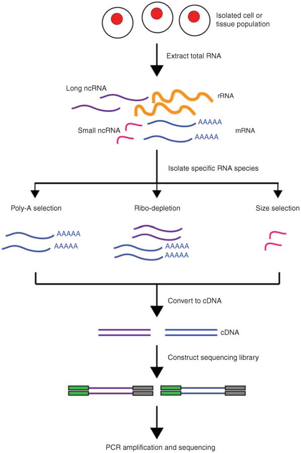

- Library preparation is typically done by sequencing facilities
- There are two main ways to select for mRNAs, which make up only a few % of RNAs: poly-A selection and ribo-depletion.
- Many samples can be “multiplexed” into a single RNA-seq library

Fig. from Kukurba & Montgomery 2015

## Sequencing considerations

- **Sequencing technology**
  - *Illumina short reads*: by far the most common
  - *PacBio or ONT long reads*: consider if sequencing full transcripts (isoforms) is key
- **Single-end vs. paired-end reads** (for Illumina)
  - Paired-end has limited added value for reference-based, gene-level workflows (but can be key in other scenarios) — but it is still common as prices are often similar
- **Sequencing “depth” / amount** — how many reads per sample
  - Guidelines highly approximate (cf. in genomics) — depends not just on transcriptome size; also on expression level distribution, expression levels of genes of interest, etc.
  - Typical recommendations are 20-50 million reads per sample (more for e.g. transcript-level inferences)

## Sequencing depth vs. replicates

For statistical power, more replicates are better than a higher sequencing depth:

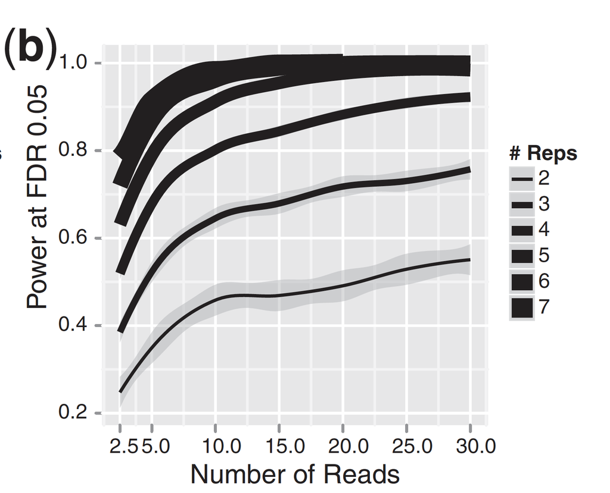

Fig. from [Liu et al. 2014](https://doi.org/10.1093/bioinformatics/btt688)

# From reads to counts

## Overview of steps

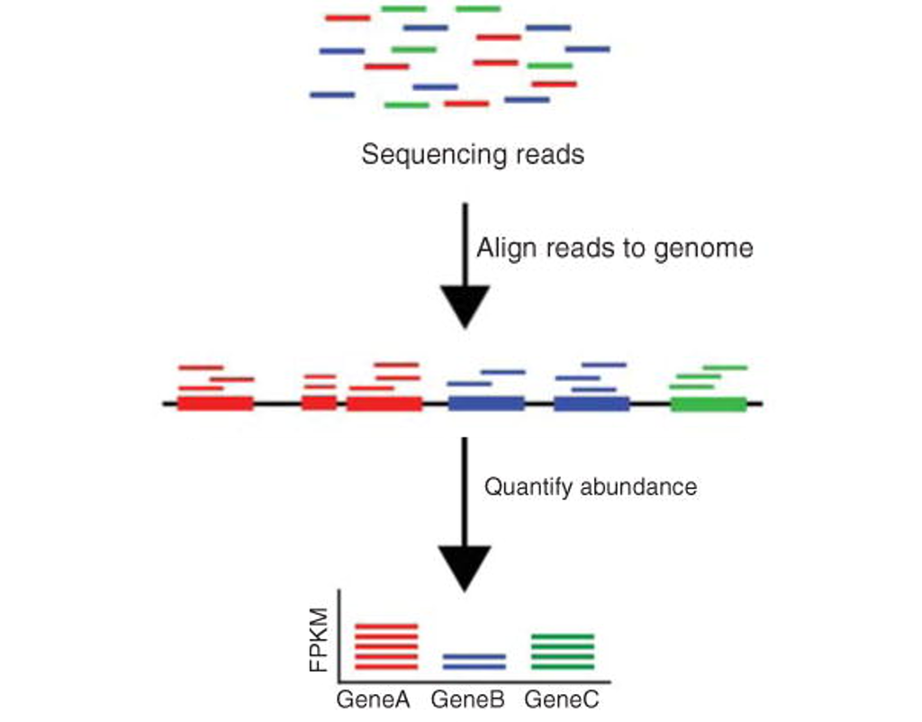

Modified after [Kukurba & Montgomery 2015](https://www.ncbi.nlm.nih.gov/pmc/articles/PMC4863231/)

## From reads to counts: overview

You will typically receive a “demultiplexed” (split-by-sample) set of **FASTQ** files.

Once you receive your data, the first series of analysis steps involves going from the raw reads to a count table (which will have a read count for each gene in each sample).

This part is **bioinformatics-heavy** with large files, a need for lots of computing power such as with a supercomputer, command-line (Unix shell) programs — it specifically involves:

1. Read preprocessing
2. Aligning reads to a reference genome (+ alignment QC)
3. Quantifying expression levels

This can be run using **standardized, one-size-fits-all workflows**, and is therefore (relatively) suitable to be outsourced to a company, facility, or collaborator.

## Reads to counts: Read pre-processing

Read pre-processing includes the following steps:

- **Checking the** **quantity and quality of your reads**
  - Does not change your data, but helps decide next steps / sample exclusion
  - Also useful to check for contamination, library complexity, and adapter content
- **Removing unwanted sequences**
  - Adapters, low-quality bases, and very short reads
  - rRNA-derived reads (*optional*)
  - Contaminant sequences (*optional*)

## Reads to counts: alignment to a reference genome

The **alignment of reads to a reference genome** needs to be *“splice-aware”*.

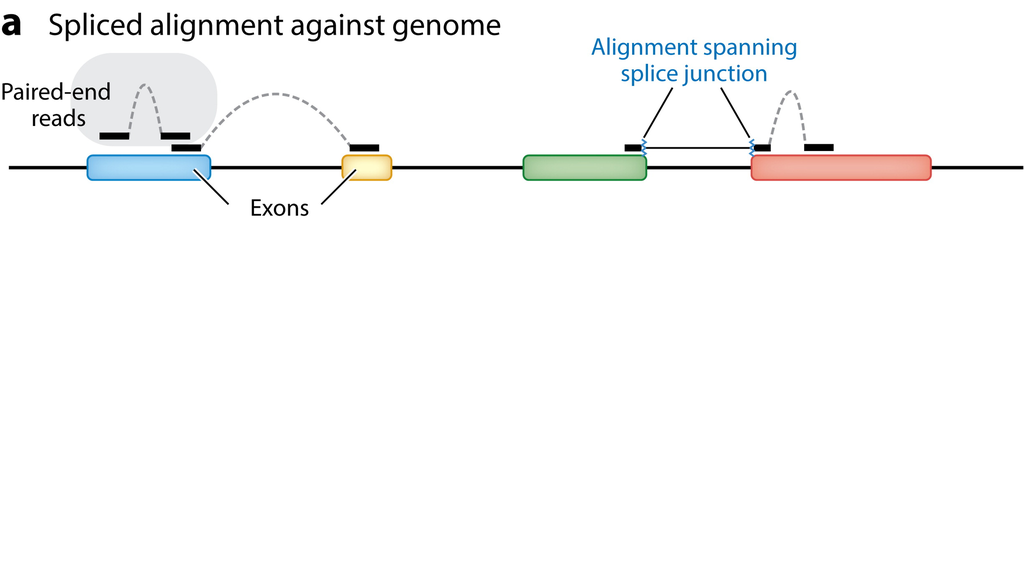

Berge et al. 2019

## Reads to counts: alignment to a reference genome

Alternatively, you can **align to the transcriptome** (i.e., all mature transcripts):

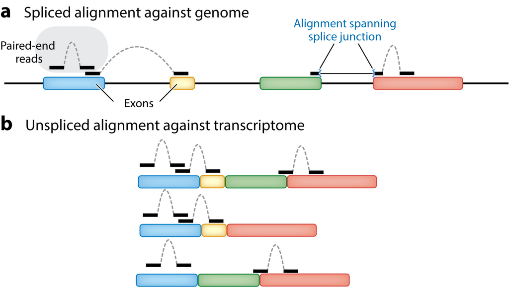

Berge et al. 2019

## Reads to counts: alignment QC

- **Alignment rates**  
  What percentage of reads was successfully aligned? (Should be >80%)
- **Alignment targets**  
  What percentages of aligned reads mapped to *exons* vs. *introns* vs. *intergenic regions*?

**What might cause high intronic mapping rates?**

An abundance of pre-mRNA versus mature-mRNA.

**What might cause high intergenic mapping rates?**

DNA contamination or poor genome assembly/annotation quality

## Reads to counts: quantification

At heart, a simple counting exercise once you have the alignments in hand.  
But made more complicated by sequencing biases and multi-mapping reads.

Current best-performing tools (e.g. `Salmon`) do **transcript-level quantification** — even though this is typically followed by **gene-level aggregation** prior to downstream analysis.

**Fast-moving field**

Several very commonly used tools like `FeatureCounts` (>15k citations) and `HTSeq` (<18k citations) have become disfavored in the past couple of years, as they e.g. don’t count multi-mapping reads at all.

## A best-practice workflow to produce counts

The “nf-core” initiative (https://nf-co.re) attempts to produce best-practice and automated workflows/pipelines, like for RNA-seq (https://nf-co.re/rnaseq):

[figure not shown]

# From counts to conclusions

## Count table analysis: overview

The second part of RNA-seq data analysis involves analyzing the count table.  
In contrast to the first part, this can be done on a laptop and instead is heavier on **statistics**, **data visualization** and **biological interpretation**.

It is typically done with the R languange, and common steps include:

- **Principal Component Analysis (PCA)**  
  Assessing overall sample clustering patterns
- **Differential Expression (DE) analysis**  
  Finding genes that differ in expression level between sample groups (DEGs)
- **Functional enrichment analysis**  
  See whether certain gene function groupings are overrepresented among DEGs

## PCA

A PCA analysis will help to visualize overall patterns of similarity among samples,  
for example whether our groups of interest cluster:

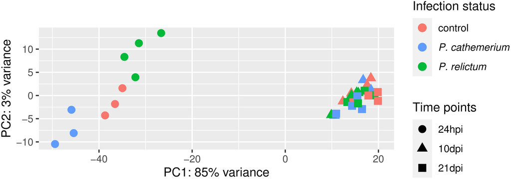

Fig. 1 from [Garrigos et al. 2023](https://doi.org/10.1111/mec.17240)

## Differential expression (DE) analysis

A Differential Expression (DE) analysis allows you to test, for every single expressed gene in your dataset, whether it significantly differs in expression level between groups.

Typically, this is done with pairwise comparisons between groups:

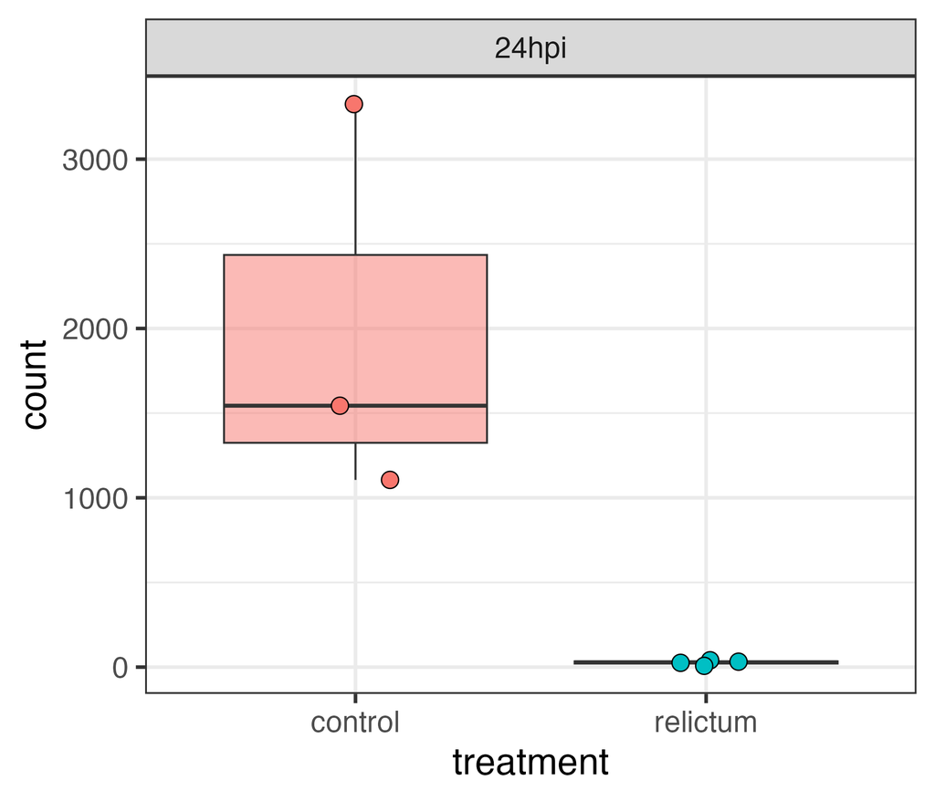

## Differential expression (DE) analysis

A Differential Expression (DE) analysis allows you to test, for every single expressed gene in your dataset, whether it significantly differs in expression level between groups.

Typically, this is done with pairwise comparisons between groups:

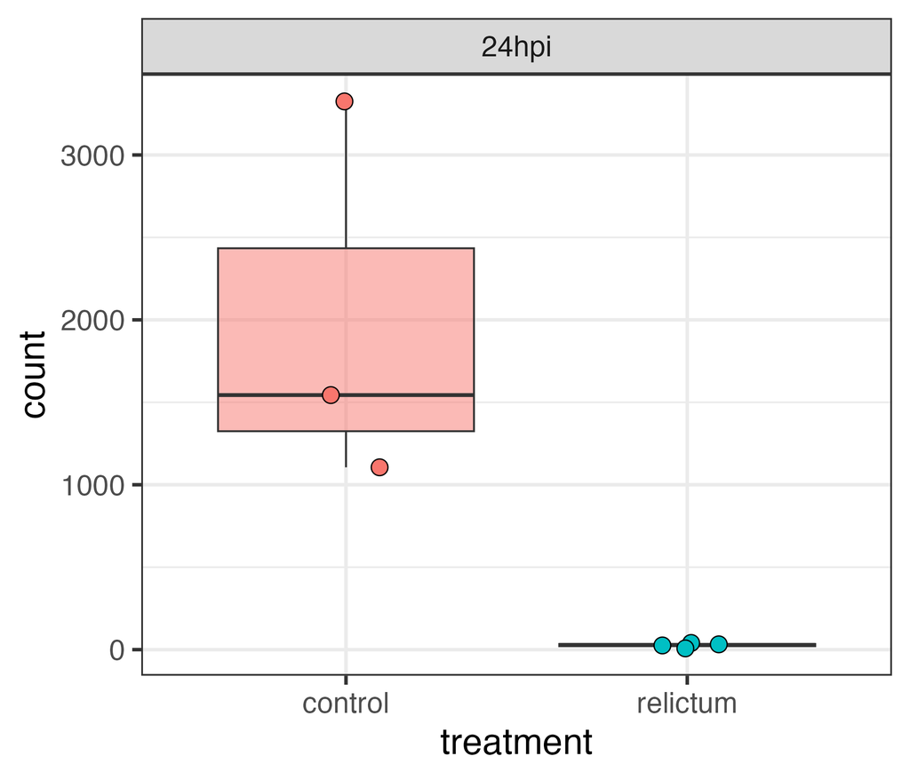

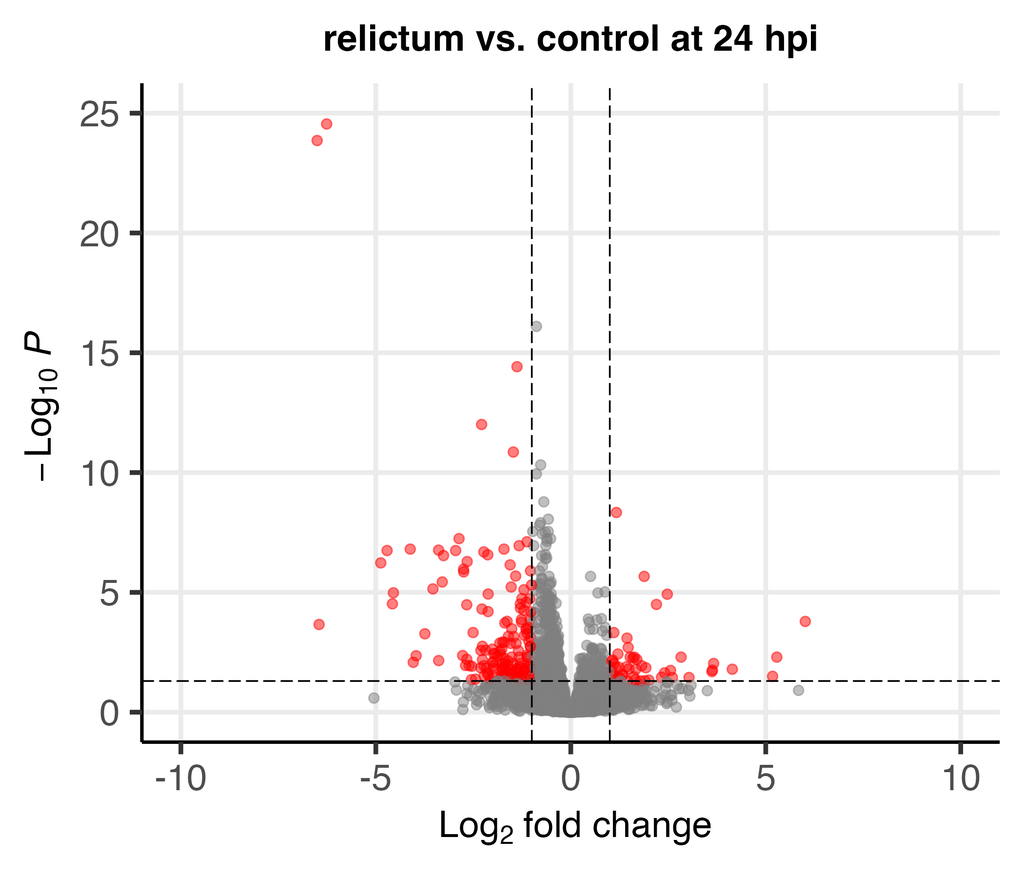

## DE analysis: general statistical considerations

- **Gene count normalization**  
  To be able to fairly compare samples, raw gene counts need to be adjusted:
  - By library size, which is the total number of gene counts per sample
  - By library composition, e.g. to correct for sample-specific extremely abundant genes that “steal” most of that sample’s counts
- **Probability distribution of the count data**
  - Gene counts have higher variance than a Poisson distribution: **negative** **binomial distribution** is typically used.
  - Variance (“dispersion”) estimates are gene-specific but “borrow” information from other genes (details beyond the scope of this lecture).

## DE analysis: general statistical considerations (cont.)

- **Multiple-testing correction**
  - 10,000+ genes are independently tested during a DE analysis, so there is a dire need for multiple testing correction.
  - The standard method is the **Benjamini-Hochberg** (BH) method.
- **Log2-fold changes (LFC) as a measure of expression difference**
  - We’ll discuss this in the lab.

**R packages to the rescue**

Specialized R/Bioconductor packages like `DESeq2` and `EdgeR` make differential expression analysis relatively straightforward and automatically take care of the abovementioned considerations (we will use `DESeq2` in the lab).

## Functional enrichment: introduction

Lists of DEGs can be quite long, and it is not always easy to make biological sense of them. Functional enrichment analyses help with this.

Functional enrichment analyses check whether certain **functional categories of genes** are **statistically overrepresented** among up- and/or downregulated genes.

There are a number of databases that group genes into functional categories, but the two main ones used for enrichment analysis are:

- **Gene Ontology (GO)**
- **Kyoto Encyclopedia of Genes and Genomes (KEGG)**

## Functional enrichment: GO

- Genes are assigned zero, one or more GO “**terms**”
- Hierarchical structure with more specific terms grouping into more general terms
- Highest-level grouping are the three “ontologies”: *Biological Process*, *Molecular Function*, *Cellular Component*

Fig. 4 from [Garrigos et al. 2023](https://doi.org/10.1111/mec.17240)

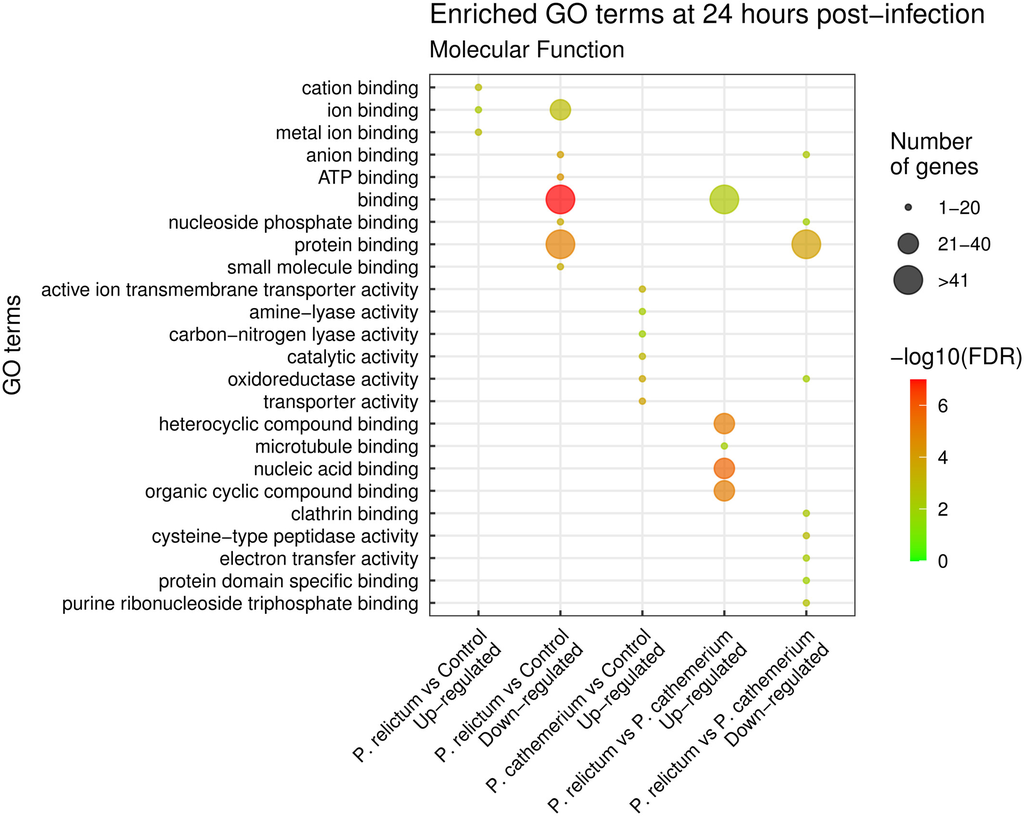

## Functional enrichment: KEGG

KEGG focuses on **pathways** for cellular and organismal functions whose genes can be drawn and connected in maps.

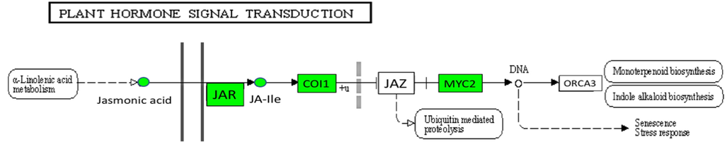

[Rodriguez et al. 2020](https://bsppjournals.onlinelibrary.wiley.com/doi/abs/10.1111/ppa.13165): “KEGG representation of up-regulated genes related to jasmonic acid (JA) signal transduction pathways (ko04075) in banana cv. Calcutta 4 after inoculation with *Pseudocercospora fijiensis*. Genes or chemicals up-regulated at any time point were highlighted in green.”

## Functional enrichment: KEGG

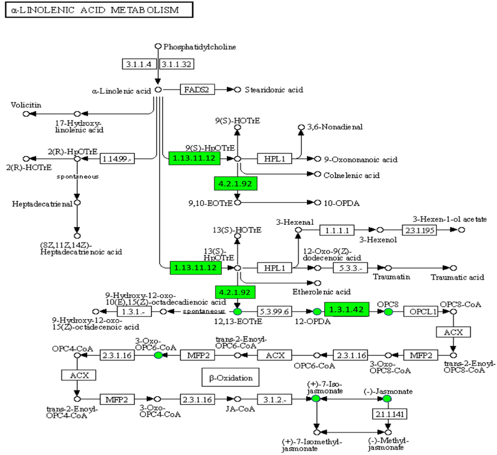

[Rodriguez et al. 2020](https://bsppjournals.onlinelibrary.wiley.com/doi/abs/10.1111/ppa.13165)